# goodreads book 書籍的評論率調查

資料來源：book1https://www.kaggle.com/jealousleopard/goodreadsbooks?fbclid=IwAR1BBVND3nG6b5gvkmwgqQNgplf_9D1U33_Es-KEloFiwNJQI9WppOfEYLU book2https://www.kaggle.com/brosen255/goodreads-books?fbclid=IwAR2zU-kP_TVk2yd0Srm-JiR1XEhuINpaqYn8Joqxj4YATFEwwML3RiYSUUw

```r
library(dplyr)
setwd("C:/Users/goodman/Desktop/")

book1<-read.csv('book1.csv')
head(book1)
```

```
##   bookID                                                        title
## 1      1    Harry Potter and the Half-Blood Prince (Harry Potter  #6)
## 2      2 Harry Potter and the Order of the Phoenix (Harry Potter  #5)
## 3      3     Harry Potter and the Sorcerer's Stone (Harry Potter  #1)
## 4      4   Harry Potter and the Chamber of Secrets (Harry Potter  #2)
## 5      5  Harry Potter and the Prisoner of Azkaban (Harry Potter  #3)
## 6      8       Harry Potter Boxed Set  Books 1-5 (Harry Potter  #1-5)
##                       authors average_rating       isbn        isbn13
## 1 J.K. Rowling-Mary GrandPrÃ©           4.56 0439785960 9780439785969
## 2 J.K. Rowling-Mary GrandPrÃ©           4.49 0439358078 9780439358071
## 3 J.K. Rowling-Mary GrandPrÃ©           4.47 0439554934 9780439554930
## 4                J.K. Rowling           4.41 0439554896 9780439554893
## 5 J.K. Rowling-Mary GrandPrÃ©           4.55 043965548X 9780439655484
## 6 J.K. Rowling-Mary GrandPrÃ©           4.78 0439682584 9780439682589
##   language_code X..num_pages ratings_count text_reviews_count
## 1           eng          652       1944099              26249
## 2           eng          870       1996446              27613
## 3           eng          320       5629932              70390
## 4           eng          352          6267                272
## 5           eng          435       2149872              33964
## 6           eng         2690         38872                154
```

```r
book2<-read.csv('book2.csv')
head(book2)
```

```
##   author_average_rating author_gender
## 1                  4.01        female
## 2                  4.15          male
## 3                  4.00        female
## 4                  3.88          male
## 5                  4.10        female
## 6                  3.77          male
##                           author_genres author_id           author_name
## 1                   historical-fiction,     74489   Victoria Thompson\n
## 2 literature-fiction,mystery-thrillers,    706255       Stieg Larsson\n
## 3                              romance,   5618190 Mimi Jean Pamfiloff\n
## 4                       fiction,memoir,     37871        JosÃ© Donoso\n
## 5                  young-adult,fantasy,     36122   Patricia C. Wrede\n
## 6                               horror,     58947         Steve Niles\n
##                            author_page_url author_rating_count
```

[output cut: 41 more lines]

備注：從book1的檔案中，先過濾出評分最高的書籍，然後在把列表（bookID,title,average_rating,text_reviews_count）select出來，然後在從網路評論率的列表中排序出高到低的順序，再選出前六筆的資料作分析：得出結論：評分越高的書籍，網路評論率顯示越低。

```r
  book1$average_rating = as.numeric(as.character(book1$average_rating))
 View(book1)
 as.numeric(as.character(book1))
```

```
##  [1] NA NA NA NA NA NA NA NA NA NA
```

```r
 book1new<-filter(book1,average_rating>=5)
  book1new<-select(book1new,bookID,title,average_rating,text_reviews_count)
  book1new<-arrange(book1new,desc(text_reviews_count))
  book1new<-head(book1new)
  book1new<-data.frame(bookID=c(17224,2843,23552,32823,36853,2034),title=c("the diamond color meditation","literature circle guide","the new big book of america","fanning the flame","tyrannosaurus wrecks","comoediae"),average_rating=c(5,5,5,5,5,5),text_reviews_count=c(3,1,1,1,1,0))
 book1new
```

```
##   bookID                        title average_rating text_reviews_count
## 1  17224 the diamond color meditation              5                  3
## 2   2843      literature circle guide              5                  1
## 3  23552  the new big book of america              5                  1
## 4  32823            fanning the flame              5                  1
## 5  36853         tyrannosaurus wrecks              5                  1
## 6   2034                    comoediae              5                  0
```

備注：從檔案book1，從其中挑選出列表（bookID,title,average_rating.text_reviews_count),再從text_reviews_count排列出其順序（從高到低），在挑選出網路評論率書籍最高的六本書。

```r
 book1new2<-select(book1,bookID,title,average_rating,text_reviews_count)
 book1new2<-arrange(book1new2,desc(text_reviews_count))
 book1new2<-head(book1new2)
 book1new2
```

```
##   bookID                                                    title
## 1  41865                                  Twilight (Twilight  #1)
## 2  19063                                           The Book Thief
## 3      3 Harry Potter and the Sorcerer's Stone (Harry Potter  #1)
## 4    865                                            The Alchemist
## 5   3636                                                The Giver
## 6  43641                                      Water for Elephants
##   average_rating text_reviews_count
## 1           3.59              93619
## 2           4.37              84237
## 3           4.47              70390
## 4           3.85              54668
## 5           4.12              54469
## 6           4.08              52449
```

```r
 book2new<-filter(book2,book_average_rating>=5)
 book2new<-select(book2new,author_id,book_average_rating,book_title,num_reviews)
 book2new<-arrange(book2new,desc(num_reviews))
 book2new<-head(book2new)
 book2new<-data.frame(author_id=c(15683552,5347676,8079735,13654965),book_title=c("christian warrior women","eyes on me.","the rhapsody of the ant woman","what we think we become"),book_average_rating=c(5,5,5,5),num_reviews=c(3,2,2,1))
 book2new
```

```
##   author_id                    book_title book_average_rating num_reviews
## 1  15683552       christian warrior women                   5           3
## 2   5347676                   eyes on me.                   5           2
## 3   8079735 the rhapsody of the ant woman                   5           2
## 4  13654965       what we think we become                   5           1
```

備注：從檔案book2，從其列表中選出（author_id,book_average_rating,book_title,num_reviews),排列出其順序，在挑選出網路評論率最高的六筆資料。

```r
 book2new2<-select(book2,author_id,book_average_rating,book_title,num_reviews)
 book2new2<-arrange(book2new2,desc(num_reviews))
 book2new2<-head(book2new2)
 book2new2
```

```
##   author_id book_average_rating                       book_title
## 1   1406384                4.24 \n      The Fault in Our Stars\n
## 2      2383                4.06              \n      Gone Girl\n
## 3      2383                4.06              \n      Gone Girl\n
## 4      2383                4.06              \n      Gone Girl\n
## 5   1063732                3.90  \n      The Girl on the Train\n
## 6   1063732                3.90  \n      The Girl on the Train\n
##   num_reviews
## 1      147696
## 2      126473
## 3      126452
## 4      126444
## 5      102739
## 6      102728
```

book1new1檔案資料視覺圖形 從goodreads書籍的書籍網站中的2019分析的書籍檔案，從13724找出評分最高的6本書籍，從這些評分最高的書籍，去探究其網絡的評論率，得出的結論，很顯然的評分高的書籍不那麽受讀者熱愛可能與其書籍類別，從這些資料中評分高的書籍，在網絡上評論的人也只有三位。

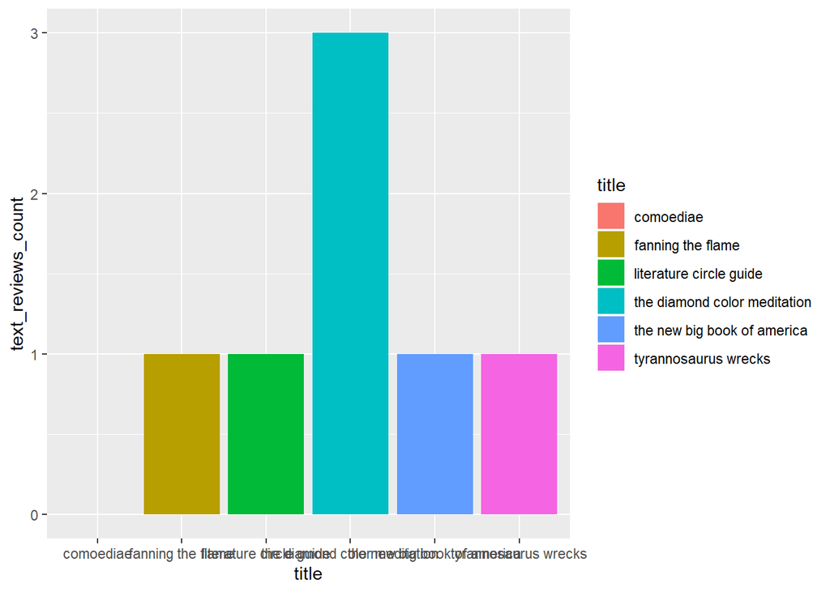

```r
library(ggplot2)
ggplot(book1new,aes(x=title,y=text_reviews_count,fill=title))+geom_bar(stat="identity")
```

book1new2檔案資料視覺圖形 從goodreads書籍的書籍網站中的2019分析的書籍檔案，13724本書籍找出評論率最高的的六本書籍，其中最高的五本書籍都是奇幻文學，曲構的文學小説，第六本這是愛情片，歷史小説。得出結論，讀者往往喜愛評論的書籍是奇幻文學小説的類別。最高的評論率有93619.

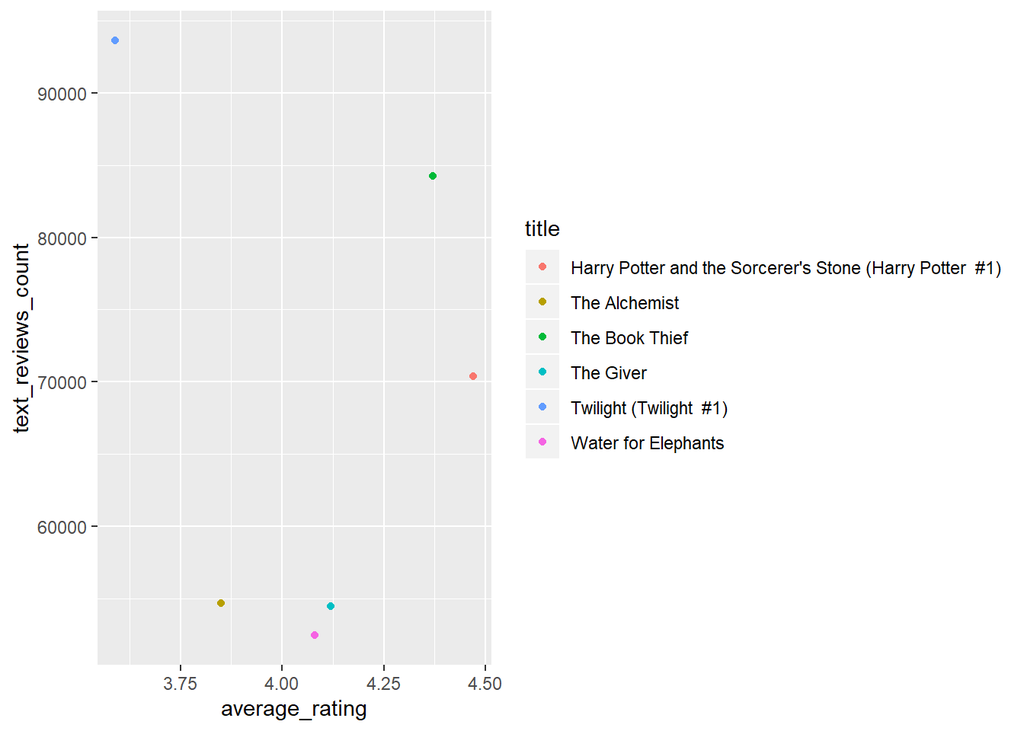

```r
library(ggplot2)
ggplot(data=book1new2)+geom_point(aes(x=average_rating,y=text_reviews_count,color=title))
```

book2new 從goodreads書籍的書籍網站中的2019分析的書籍第二份檔案，22891本書籍找出評分最高前四本書籍，探究出其網絡評論率，得出結論評分高的書籍，往往不那麽受讀者歡迎，最高的評論率也只有三位而已。

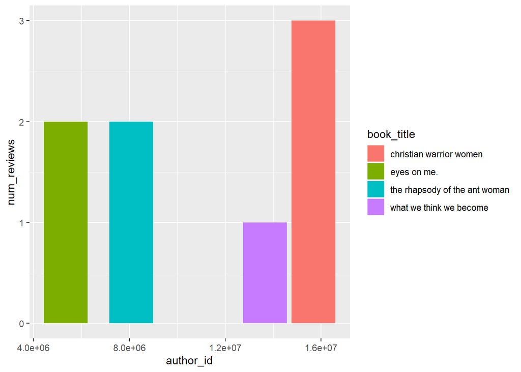

```r
ggplot(book2new,aes(x=author_id,y=num_reviews,fill=book_title))+geom_bar(stat="identity")
```

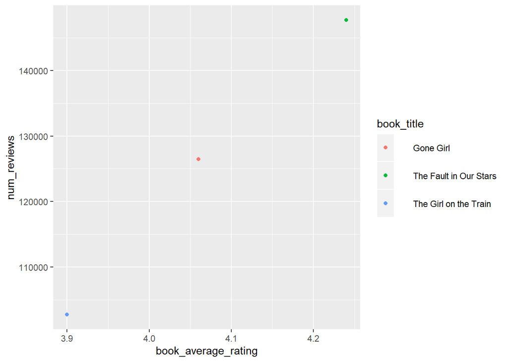

```r
ggplot(data=book2new2)+geom_point(aes(x=book_average_rating,y=num_reviews,color=book_title))
```